# Risk Factor Analysis

## Outcome Variable

**Outcome Variable:** ever_swasted

## Predictor Variables

**Intervention Variable:** fage

**Adjustment Set:**

unadjusted

## Stratifying Variables

The analysis was stratified on these variable(s):

- agecat
- studyid
- country

## Data Summary

| agecat | studyid | country | fage | ever_swasted | n_cell | n |
| --- | --- | --- | --- | --- | --- | --- |
| 0-24 months | COHORTS | GUATEMALA | >=38 | 0 | 357 | 1285 |
| 0-24 months | COHORTS | GUATEMALA | >=38 | 1 | 25 | 1285 |
| 0-24 months | COHORTS | GUATEMALA | <32 | 0 | 554 | 1285 |
| 0-24 months | COHORTS | GUATEMALA | <32 | 1 | 47 | 1285 |
| 0-24 months | COHORTS | GUATEMALA | [32-38) | 0 | 280 | 1285 |
| 0-24 months | COHORTS | GUATEMALA | [32-38) | 1 | 22 | 1285 |
| 0-24 months | COHORTS | PHILIPPINES | >=38 | 0 | 285 | 2939 |
| 0-24 months | COHORTS | PHILIPPINES | >=38 | 1 | 43 | 2939 |
| 0-24 months | COHORTS | PHILIPPINES | <32 | 0 | 1823 | 2939 |
| 0-24 months | COHORTS | PHILIPPINES | <32 | 1 | 251 | 2939 |
| 0-24 months | COHORTS | PHILIPPINES | [32-38) | 0 | 466 | 2939 |
| 0-24 months | COHORTS | PHILIPPINES | [32-38) | 1 | 71 | 2939 |
| 0-24 months | LCNI-5 | MALAWI | >=38 | 0 | 26 | 106 |
| 0-24 months | LCNI-5 | MALAWI | >=38 | 1 | 0 | 106 |
| 0-24 months | LCNI-5 | MALAWI | <32 | 0 | 56 | 106 |
| 0-24 months | LCNI-5 | MALAWI | <32 | 1 | 0 | 106 |
| 0-24 months | LCNI-5 | MALAWI | [32-38) | 0 | 24 | 106 |
| 0-24 months | LCNI-5 | MALAWI | [32-38) | 1 | 0 | 106 |
| 0-24 months | MAL-ED | BANGLADESH | >=38 | 0 | 63 | 151 |
| 0-24 months | MAL-ED | BANGLADESH | >=38 | 1 | 6 | 151 |
| 0-24 months | MAL-ED | BANGLADESH | <32 | 0 | 28 | 151 |
| 0-24 months | MAL-ED | BANGLADESH | <32 | 1 | 2 | 151 |
| 0-24 months | MAL-ED | BANGLADESH | [32-38) | 0 | 46 | 151 |
| 0-24 months | MAL-ED | BANGLADESH | [32-38) | 1 | 6 | 151 |
| 0-24 months | MAL-ED | BRAZIL | >=38 | 0 | 30 | 79 |
| 0-24 months | MAL-ED | BRAZIL | >=38 | 1 | 0 | 79 |
| 0-24 months | MAL-ED | BRAZIL | <32 | 0 | 18 | 79 |
| 0-24 months | MAL-ED | BRAZIL | <32 | 1 | 0 | 79 |
| 0-24 months | MAL-ED | BRAZIL | [32-38) | 0 | 31 | 79 |
| 0-24 months | MAL-ED | BRAZIL | [32-38) | 1 | 0 | 79 |

[output cut: 204 more lines]

The following strata were considered:

- agecat: 0-24 months, studyid: COHORTS, country: GUATEMALA
- agecat: 0-24 months, studyid: COHORTS, country: PHILIPPINES
- agecat: 0-24 months, studyid: LCNI-5, country: MALAWI
- agecat: 0-24 months, studyid: MAL-ED, country: BANGLADESH
- agecat: 0-24 months, studyid: MAL-ED, country: BRAZIL
- agecat: 0-24 months, studyid: MAL-ED, country: INDIA
- agecat: 0-24 months, studyid: MAL-ED, country: NEPAL
- agecat: 0-24 months, studyid: MAL-ED, country: PERU
- agecat: 0-24 months, studyid: MAL-ED, country: SOUTH AFRICA
- agecat: 0-24 months, studyid: MAL-ED, country: TANZANIA, UNITED REPUBLIC OF
- agecat: 0-24 months, studyid: PROBIT, country: BELARUS
- agecat: 0-24 months, studyid: SAS-CompFeed, country: INDIA
- agecat: 0-24 months, studyid: SAS-FoodSuppl, country: INDIA
- agecat: 0-6 months, studyid: COHORTS, country: GUATEMALA
- agecat: 0-6 months, studyid: COHORTS, country: PHILIPPINES
- agecat: 0-6 months, studyid: LCNI-5, country: MALAWI
- agecat: 0-6 months, studyid: MAL-ED, country: BANGLADESH
- agecat: 0-6 months, studyid: MAL-ED, country: BRAZIL
- agecat: 0-6 months, studyid: MAL-ED, country: INDIA
- agecat: 0-6 months, studyid: MAL-ED, country: NEPAL
- agecat: 0-6 months, studyid: MAL-ED, country: PERU
- agecat: 0-6 months, studyid: MAL-ED, country: SOUTH AFRICA
- agecat: 0-6 months, studyid: MAL-ED, country: TANZANIA, UNITED REPUBLIC OF
- agecat: 0-6 months, studyid: PROBIT, country: BELARUS
- agecat: 0-6 months, studyid: SAS-CompFeed, country: INDIA
- agecat: 0-6 months, studyid: SAS-FoodSuppl, country: INDIA
- agecat: 6-24 months, studyid: COHORTS, country: GUATEMALA
- agecat: 6-24 months, studyid: COHORTS, country: PHILIPPINES
- agecat: 6-24 months, studyid: LCNI-5, country: MALAWI
- agecat: 6-24 months, studyid: MAL-ED, country: BANGLADESH
- agecat: 6-24 months, studyid: MAL-ED, country: BRAZIL
- agecat: 6-24 months, studyid: MAL-ED, country: INDIA
- agecat: 6-24 months, studyid: MAL-ED, country: NEPAL
- agecat: 6-24 months, studyid: MAL-ED, country: PERU
- agecat: 6-24 months, studyid: MAL-ED, country: SOUTH AFRICA
- agecat: 6-24 months, studyid: MAL-ED, country: TANZANIA, UNITED REPUBLIC OF
- agecat: 6-24 months, studyid: PROBIT, country: BELARUS
- agecat: 6-24 months, studyid: SAS-CompFeed, country: INDIA
- agecat: 6-24 months, studyid: SAS-FoodSuppl, country: INDIA

### Dropped Strata

Some strata were dropped due to rare outcomes:

- agecat: 0-24 months, studyid: LCNI-5, country: MALAWI
- agecat: 0-24 months, studyid: MAL-ED, country: BANGLADESH
- agecat: 0-24 months, studyid: MAL-ED, country: BRAZIL
- agecat: 0-24 months, studyid: MAL-ED, country: INDIA
- agecat: 0-24 months, studyid: MAL-ED, country: NEPAL
- agecat: 0-24 months, studyid: MAL-ED, country: PERU
- agecat: 0-24 months, studyid: MAL-ED, country: SOUTH AFRICA
- agecat: 0-24 months, studyid: MAL-ED, country: TANZANIA, UNITED REPUBLIC OF
- agecat: 0-6 months, studyid: LCNI-5, country: MALAWI
- agecat: 0-6 months, studyid: MAL-ED, country: BANGLADESH
- agecat: 0-6 months, studyid: MAL-ED, country: BRAZIL
- agecat: 0-6 months, studyid: MAL-ED, country: INDIA
- agecat: 0-6 months, studyid: MAL-ED, country: NEPAL
- agecat: 0-6 months, studyid: MAL-ED, country: PERU
- agecat: 0-6 months, studyid: MAL-ED, country: SOUTH AFRICA
- agecat: 0-6 months, studyid: MAL-ED, country: TANZANIA, UNITED REPUBLIC OF
- agecat: 6-24 months, studyid: LCNI-5, country: MALAWI
- agecat: 6-24 months, studyid: MAL-ED, country: BANGLADESH
- agecat: 6-24 months, studyid: MAL-ED, country: BRAZIL
- agecat: 6-24 months, studyid: MAL-ED, country: INDIA
- agecat: 6-24 months, studyid: MAL-ED, country: NEPAL
- agecat: 6-24 months, studyid: MAL-ED, country: PERU
- agecat: 6-24 months, studyid: MAL-ED, country: SOUTH AFRICA
- agecat: 6-24 months, studyid: MAL-ED, country: TANZANIA, UNITED REPUBLIC OF
- agecat: 6-24 months, studyid: PROBIT, country: BELARUS

## Methods Detail

We’re interested in the causal parameters $E[Y_a]$ for all values of $a \in \mathcal{A}$. These parameters represent the mean outcome if, possibly contrary to fact, we intervened to set all units to have $A=a$. Under the randomization and positivity assumptions, these are identified by the statistical parameters $\psi_a=E_W[E_{Y|A,W}(Y|A=a,W)]$. In addition, we’re interested in the mean of $Y$, $E[Y]$ under no intervention (the observed mean). We will estimate these parameters by using SuperLearner to fit the relevant likelihood factors – $E_{Y|A,W}(Y|A=a,W)$ and $p(A=a|W)$, and then updating our likelihood fit using a joint TMLE.

For unadjusted analyses ($W=\{\}$), initial likelihoods were estimated using Lrnr_glm to estimate the simple $E(Y|A)$ and Lrnr_mean to estimate $p(A)$. For adjusted analyses, a small library containing Lrnr_glmnet, Lrnr_xgboost, and Lrnr_mean was used.

Having estimated these parameters, we will then use the delta method to estimate relative risks and attributable risks relative to a prespecified baseline level of $A$.

# Results Detail

## Results Plots

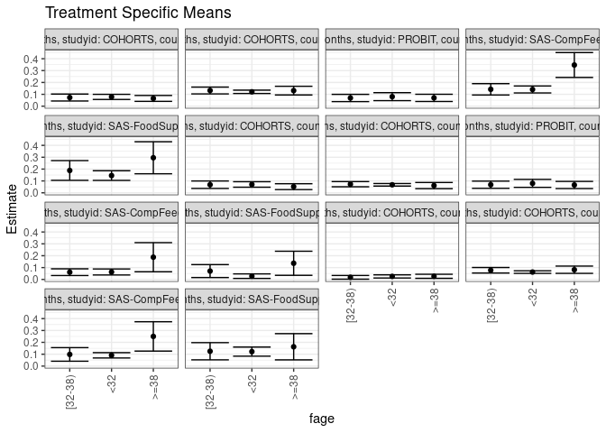

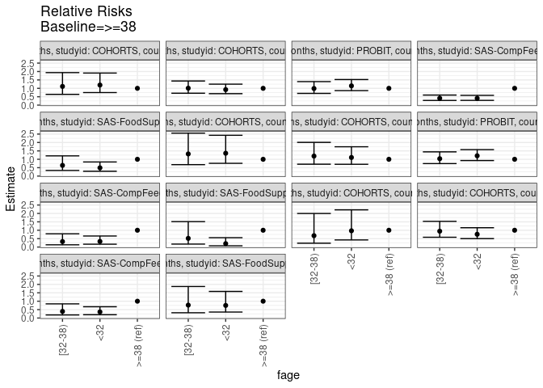

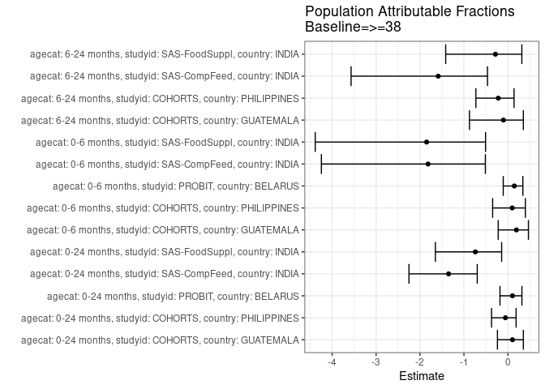

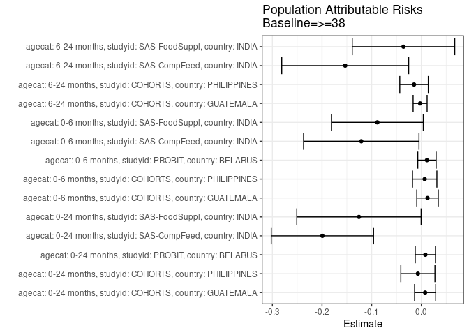

## Results Table

### Parameter: TSM

| agecat | studyid | country | intervention_level | baseline_level | estimate | ci_lower | ci_upper |
| --- | --- | --- | --- | --- | --- | --- | --- |
| 0-24 months | COHORTS | GUATEMALA | >=38 | NA | 0.0654450 | 0.0406351 | 0.0902550 |
| 0-24 months | COHORTS | GUATEMALA | <32 | NA | 0.0782030 | 0.0567292 | 0.0996768 |
| 0-24 months | COHORTS | GUATEMALA | [32-38) | NA | 0.0728477 | 0.0435254 | 0.1021699 |
| 0-24 months | COHORTS | PHILIPPINES | >=38 | NA | 0.1310976 | 0.0945660 | 0.1676291 |
| 0-24 months | COHORTS | PHILIPPINES | <32 | NA | 0.1210222 | 0.1069831 | 0.1350613 |
| 0-24 months | COHORTS | PHILIPPINES | [32-38) | NA | 0.1322160 | 0.1035622 | 0.1608698 |
| 0-24 months | PROBIT | BELARUS | >=38 | NA | 0.0698925 | 0.0395679 | 0.1002171 |
| 0-24 months | PROBIT | BELARUS | <32 | NA | 0.0801746 | 0.0465423 | 0.1138069 |
| 0-24 months | PROBIT | BELARUS | [32-38) | NA | 0.0690909 | 0.0385422 | 0.0996396 |
| 0-24 months | SAS-CompFeed | INDIA | >=38 | NA | 0.3469388 | 0.2419587 | 0.4519189 |
| 0-24 months | SAS-CompFeed | INDIA | <32 | NA | 0.1408228 | 0.1113519 | 0.1702937 |
| 0-24 months | SAS-CompFeed | INDIA | [32-38) | NA | 0.1421320 | 0.0944028 | 0.1898612 |
| 0-24 months | SAS-FoodSuppl | INDIA | >=38 | NA | 0.2954545 | 0.1604832 | 0.4304259 |
| 0-24 months | SAS-FoodSuppl | INDIA | <32 | NA | 0.1453287 | 0.1046474 | 0.1860100 |
| 0-24 months | SAS-FoodSuppl | INDIA | [32-38) | NA | 0.1882353 | 0.1050351 | 0.2714355 |
| 0-6 months | COHORTS | GUATEMALA | >=38 | NA | 0.0517799 | 0.0270618 | 0.0764981 |
| 0-6 months | COHORTS | GUATEMALA | <32 | NA | 0.0703625 | 0.0472045 | 0.0935204 |
| 0-6 months | COHORTS | GUATEMALA | [32-38) | NA | 0.0682731 | 0.0369309 | 0.0996153 |
| 0-6 months | COHORTS | PHILIPPINES | >=38 | NA | 0.0609756 | 0.0350755 | 0.0868757 |
| 0-6 months | COHORTS | PHILIPPINES | <32 | NA | 0.0675350 | 0.0567305 | 0.0783394 |
| 0-6 months | COHORTS | PHILIPPINES | [32-38) | NA | 0.0726257 | 0.0506720 | 0.0945794 |
| 0-6 months | PROBIT | BELARUS | >=38 | NA | 0.0659489 | 0.0359348 | 0.0959629 |
| 0-6 months | PROBIT | BELARUS | <32 | NA | 0.0796508 | 0.0459641 | 0.1133375 |
| 0-6 months | PROBIT | BELARUS | [32-38) | NA | 0.0682828 | 0.0379291 | 0.0986365 |
| 0-6 months | SAS-CompFeed | INDIA | >=38 | NA | 0.1875000 | 0.0647763 | 0.3102237 |
| 0-6 months | SAS-CompFeed | INDIA | <32 | NA | 0.0627981 | 0.0374492 | 0.0881470 |
| 0-6 months | SAS-CompFeed | INDIA | [32-38) | NA | 0.0612245 | 0.0329168 | 0.0895321 |
| 0-6 months | SAS-FoodSuppl | INDIA | >=38 | NA | 0.1363636 | 0.0348425 | 0.2378848 |
| 0-6 months | SAS-FoodSuppl | INDIA | <32 | NA | 0.0276817 | 0.0087443 | 0.0466190 |
| 0-6 months | SAS-FoodSuppl | INDIA | [32-38) | NA | 0.0705882 | 0.0160716 | 0.1251049 |
| 6-24 months | COHORTS | GUATEMALA | >=38 | NA | 0.0264706 | 0.0093999 | 0.0435413 |
| 6-24 months | COHORTS | GUATEMALA | <32 | NA | 0.0256410 | 0.0123773 | 0.0389047 |
| 6-24 months | COHORTS | GUATEMALA | [32-38) | NA | 0.0179211 | 0.0023476 | 0.0334947 |
| 6-24 months | COHORTS | PHILIPPINES | >=38 | NA | 0.0819672 | 0.0511760 | 0.1127585 |
| 6-24 months | COHORTS | PHILIPPINES | <32 | NA | 0.0622711 | 0.0514348 | 0.0731073 |
| 6-24 months | COHORTS | PHILIPPINES | [32-38) | NA | 0.0773810 | 0.0540495 | 0.1007124 |
| 6-24 months | SAS-CompFeed | INDIA | >=38 | NA | 0.2500000 | 0.1262891 | 0.3737109 |
| 6-24 months | SAS-CompFeed | INDIA | <32 | NA | 0.0906758 | 0.0681797 | 0.1131719 |
| 6-24 months | SAS-CompFeed | INDIA | [32-38) | NA | 0.0982659 | 0.0410380 | 0.1554938 |
| 6-24 months | SAS-FoodSuppl | INDIA | >=38 | NA | 0.1627907 | 0.0523100 | 0.2732714 |
| 6-24 months | SAS-FoodSuppl | INDIA | <32 | NA | 0.1218638 | 0.0834307 | 0.1602969 |
| 6-24 months | SAS-FoodSuppl | INDIA | [32-38) | NA | 0.1250000 | 0.0524390 | 0.1975610 |

### Parameter: E(Y)

| agecat | studyid | country | intervention_level | baseline_level | estimate | ci_lower | ci_upper |
| --- | --- | --- | --- | --- | --- | --- | --- |
| 0-24 months | COHORTS | GUATEMALA | NA | NA | 0.0731518 | 0.0589094 | 0.0873941 |
| 0-24 months | COHORTS | PHILIPPINES | NA | NA | 0.1241919 | 0.1122665 | 0.1361173 |
| 0-24 months | PROBIT | BELARUS | NA | NA | 0.0780194 | 0.0455878 | 0.1104510 |
| 0-24 months | SAS-CompFeed | INDIA | NA | NA | 0.1476821 | 0.1188009 | 0.1765633 |
| 0-24 months | SAS-FoodSuppl | INDIA | NA | NA | 0.1698565 | 0.1338154 | 0.2058975 |
| 0-6 months | COHORTS | GUATEMALA | NA | NA | 0.0642648 | 0.0492598 | 0.0792699 |
| 0-6 months | COHORTS | PHILIPPINES | NA | NA | 0.0677332 | 0.0586452 | 0.0768211 |
| 0-6 months | PROBIT | BELARUS | NA | NA | 0.0772965 | 0.0448202 | 0.1097727 |
| 0-6 months | SAS-CompFeed | INDIA | NA | NA | 0.0665779 | 0.0427569 | 0.0903989 |
| 0-6 months | SAS-FoodSuppl | INDIA | NA | NA | 0.0478469 | 0.0273607 | 0.0683330 |
| 6-24 months | COHORTS | GUATEMALA | NA | NA | 0.0240343 | 0.0152359 | 0.0328328 |
| 6-24 months | COHORTS | PHILIPPINES | NA | NA | 0.0672794 | 0.0578635 | 0.0766953 |
| 6-24 months | SAS-CompFeed | INDIA | NA | NA | 0.0966811 | 0.0731505 | 0.1202117 |
| 6-24 months | SAS-FoodSuppl | INDIA | NA | NA | 0.1268657 | 0.0942904 | 0.1594410 |

### Parameter: RR

| agecat | studyid | country | intervention_level | baseline_level | estimate | ci_lower | ci_upper |
| --- | --- | --- | --- | --- | --- | --- | --- |
| 0-24 months | COHORTS | GUATEMALA | >=38 | >=38 | 1.0000000 | 1.0000000 | 1.0000000 |
| 0-24 months | COHORTS | GUATEMALA | <32 | >=38 | 1.1949418 | 0.7482645 | 1.9082635 |
| 0-24 months | COHORTS | GUATEMALA | [32-38) | >=38 | 1.1131126 | 0.6403310 | 1.9349673 |
| 0-24 months | COHORTS | PHILIPPINES | >=38 | >=38 | 1.0000000 | 1.0000000 | 1.0000000 |
| 0-24 months | COHORTS | PHILIPPINES | <32 | >=38 | 0.9231459 | 0.6826255 | 1.2484127 |
| 0-24 months | COHORTS | PHILIPPINES | [32-38) | >=38 | 1.0085315 | 0.7085618 | 1.4354933 |
| 0-24 months | PROBIT | BELARUS | >=38 | >=38 | 1.0000000 | 1.0000000 | 1.0000000 |
| 0-24 months | PROBIT | BELARUS | <32 | >=38 | 1.1471134 | 0.8645771 | 1.5219800 |
| 0-24 months | PROBIT | BELARUS | [32-38) | >=38 | 0.9885315 | 0.6980627 | 1.3998663 |
| 0-24 months | SAS-CompFeed | INDIA | >=38 | >=38 | 1.0000000 | 1.0000000 | 1.0000000 |
| 0-24 months | SAS-CompFeed | INDIA | <32 | >=38 | 0.4059010 | 0.2828679 | 0.5824472 |
| 0-24 months | SAS-CompFeed | INDIA | [32-38) | >=38 | 0.4096745 | 0.2802226 | 0.5989282 |
| 0-24 months | SAS-FoodSuppl | INDIA | >=38 | >=38 | 1.0000000 | 1.0000000 | 1.0000000 |
| 0-24 months | SAS-FoodSuppl | INDIA | <32 | >=38 | 0.4918818 | 0.2878585 | 0.8405091 |
| 0-24 months | SAS-FoodSuppl | INDIA | [32-38) | >=38 | 0.6371041 | 0.3374036 | 1.2030152 |
| 0-6 months | COHORTS | GUATEMALA | >=38 | >=38 | 1.0000000 | 1.0000000 | 1.0000000 |
| 0-6 months | COHORTS | GUATEMALA | <32 | >=38 | 1.3588753 | 0.7609608 | 2.4265928 |
| 0-6 months | COHORTS | GUATEMALA | [32-38) | >=38 | 1.3185241 | 0.6799227 | 2.5569169 |
| 0-6 months | COHORTS | PHILIPPINES | >=38 | >=38 | 1.0000000 | 1.0000000 | 1.0000000 |
| 0-6 months | COHORTS | PHILIPPINES | <32 | >=38 | 1.1075736 | 0.7034774 | 1.7437933 |
| 0-6 months | COHORTS | PHILIPPINES | [32-38) | >=38 | 1.1910615 | 0.7071598 | 2.0060917 |
| 0-6 months | PROBIT | BELARUS | >=38 | >=38 | 1.0000000 | 1.0000000 | 1.0000000 |
| 0-6 months | PROBIT | BELARUS | <32 | >=38 | 1.2077656 | 0.9258969 | 1.5754431 |
| 0-6 months | PROBIT | BELARUS | [32-38) | >=38 | 1.0353906 | 0.7437524 | 1.4413853 |
| 0-6 months | SAS-CompFeed | INDIA | >=38 | >=38 | 1.0000000 | 1.0000000 | 1.0000000 |
| 0-6 months | SAS-CompFeed | INDIA | <32 | >=38 | 0.3349232 | 0.1704948 | 0.6579294 |
| 0-6 months | SAS-CompFeed | INDIA | [32-38) | >=38 | 0.3265306 | 0.1350830 | 0.7893089 |
| 0-6 months | SAS-FoodSuppl | INDIA | >=38 | >=38 | 1.0000000 | 1.0000000 | 1.0000000 |
| 0-6 months | SAS-FoodSuppl | INDIA | <32 | >=38 | 0.2029988 | 0.0738566 | 0.5579534 |
| 0-6 months | SAS-FoodSuppl | INDIA | [32-38) | >=38 | 0.5176471 | 0.1770741 | 1.5132562 |
| 6-24 months | COHORTS | GUATEMALA | >=38 | >=38 | 1.0000000 | 1.0000000 | 1.0000000 |
| 6-24 months | COHORTS | GUATEMALA | <32 | >=38 | 0.9686610 | 0.4237702 | 2.2141811 |
| 6-24 months | COHORTS | GUATEMALA | [32-38) | >=38 | 0.6770211 | 0.2294185 | 1.9979103 |
| 6-24 months | COHORTS | PHILIPPINES | >=38 | >=38 | 1.0000000 | 1.0000000 | 1.0000000 |
| 6-24 months | COHORTS | PHILIPPINES | <32 | >=38 | 0.7597070 | 0.5021662 | 1.1493300 |
| 6-24 months | COHORTS | PHILIPPINES | [32-38) | >=38 | 0.9440476 | 0.5831743 | 1.5282324 |
| 6-24 months | SAS-CompFeed | INDIA | >=38 | >=38 | 1.0000000 | 1.0000000 | 1.0000000 |
| 6-24 months | SAS-CompFeed | INDIA | <32 | >=38 | 0.3627032 | 0.1960684 | 0.6709576 |
| 6-24 months | SAS-CompFeed | INDIA | [32-38) | >=38 | 0.3930636 | 0.1835928 | 0.8415306 |
| 6-24 months | SAS-FoodSuppl | INDIA | >=38 | >=38 | 1.0000000 | 1.0000000 | 1.0000000 |
| 6-24 months | SAS-FoodSuppl | INDIA | <32 | >=38 | 0.7485919 | 0.3541879 | 1.5821822 |
| 6-24 months | SAS-FoodSuppl | INDIA | [32-38) | >=38 | 0.7678571 | 0.3143617 | 1.8755611 |

### Parameter: PAR

| agecat | studyid | country | intervention_level | baseline_level | estimate | ci_lower | ci_upper |
| --- | --- | --- | --- | --- | --- | --- | --- |
| 0-24 months | COHORTS | GUATEMALA | >=38 | NA | 0.0077067 | -0.0135633 | 0.0289767 |
| 0-24 months | COHORTS | PHILIPPINES | >=38 | NA | -0.0069057 | -0.0412406 | 0.0274293 |
| 0-24 months | PROBIT | BELARUS | >=38 | NA | 0.0081269 | -0.0122799 | 0.0285338 |
| 0-24 months | SAS-CompFeed | INDIA | >=38 | NA | -0.1992567 | -0.3022883 | -0.0962251 |
| 0-24 months | SAS-FoodSuppl | INDIA | >=38 | NA | -0.1255981 | -0.2508220 | -0.0003742 |
| 0-6 months | COHORTS | GUATEMALA | >=38 | NA | 0.0124849 | -0.0091594 | 0.0341292 |
| 0-6 months | COHORTS | PHILIPPINES | >=38 | NA | 0.0067575 | -0.0178113 | 0.0313264 |
| 0-6 months | PROBIT | BELARUS | >=38 | NA | 0.0113476 | -0.0071376 | 0.0298328 |
| 0-6 months | SAS-CompFeed | INDIA | >=38 | NA | -0.1209221 | -0.2371560 | -0.0046882 |
| 0-6 months | SAS-FoodSuppl | INDIA | >=38 | NA | -0.0885167 | -0.1810177 | 0.0039842 |
| 6-24 months | COHORTS | GUATEMALA | >=38 | NA | -0.0024363 | -0.0165334 | 0.0116609 |
| 6-24 months | COHORTS | PHILIPPINES | >=38 | NA | -0.0146878 | -0.0433955 | 0.0140199 |
| 6-24 months | SAS-CompFeed | INDIA | >=38 | NA | -0.1533189 | -0.2811576 | -0.0254802 |
| 6-24 months | SAS-FoodSuppl | INDIA | >=38 | NA | -0.0359250 | -0.1391525 | 0.0673024 |

### Parameter: PAF

| agecat | studyid | country | intervention_level | baseline_level | estimate | ci_lower | ci_upper |
| --- | --- | --- | --- | --- | --- | --- | --- |
| 0-24 months | COHORTS | GUATEMALA | >=38 | NA | 0.1053526 | -0.2373655 | 0.3531466 |
| 0-24 months | COHORTS | PHILIPPINES | >=38 | NA | -0.0556047 | -0.3716075 | 0.1875946 |
| 0-24 months | PROBIT | BELARUS | >=38 | NA | 0.1041656 | -0.1799522 | 0.3198714 |
| 0-24 months | SAS-CompFeed | INDIA | >=38 | NA | -1.3492267 | -2.2513526 | -0.6974062 |
| 0-24 months | SAS-FoodSuppl | INDIA | >=38 | NA | -0.7394366 | -1.6501621 | -0.1416810 |
| 0-6 months | COHORTS | GUATEMALA | >=38 | NA | 0.1942728 | -0.2197063 | 0.4677437 |
| 0-6 months | COHORTS | PHILIPPINES | >=38 | NA | 0.0997671 | -0.3466070 | 0.3981769 |
| 0-6 months | PROBIT | BELARUS | >=38 | NA | 0.1468063 | -0.1053918 | 0.3414648 |
| 0-6 months | SAS-CompFeed | INDIA | >=38 | NA | -1.8162500 | -4.2450610 | -0.5121395 |
| 0-6 months | SAS-FoodSuppl | INDIA | >=38 | NA | -1.8500000 | -4.3856396 | -0.5081774 |
| 6-24 months | COHORTS | GUATEMALA | >=38 | NA | -0.1013655 | -0.8740452 | 0.3527338 |
| 6-24 months | COHORTS | PHILIPPINES | >=38 | NA | -0.2183105 | -0.7279894 | 0.1410361 |
| 6-24 months | SAS-CompFeed | INDIA | >=38 | NA | -1.5858209 | -3.5694431 | -0.4633008 |
| 6-24 months | SAS-FoodSuppl | INDIA | >=38 | NA | -0.2831737 | -1.4153842 | 0.3183135 |